# Analyse des Facteurs de Risque Cardiovasculaire (Cohorte Framingham) - Analyse en Cas Complets

## Introduction et Configuration

### Objectifs Principaux :

Ce document analyse les données de la cohorte Framingham pour explorer les relations entre les facteurs de risque et l’évolution cardiovasculaire.

- **Thème 1 (Hypertension & AVC)** : Comprendre la trajectoire de la pression artérielle (`SYSBP`) et évaluer son rôle en tant que facteur de risque de survenue d’AVC (`STROKE`).
- **Thème 2 (Tabac, Cholestérol & Maladie Coronarienne)** : Comprendre la trajectoire du cholestérol (`TOTCHOL`), l’influence du tabagisme (`CURSMOKE`) sur celle-ci, et évaluer le rôle du tabagisme comme facteur de risque de maladie coronarienne (`ANYCHD`).

### Chargement des bibliothèques

```r
library(riskCommunicator)
library(tidyverse)
library(naniar)
library(gtsummary)
library(kableExtra)
library(scales)
library(broom)
library(broom.mixed)
library(lme4)
library(survival)
library(survminer)
```

## Préparation et Nettoyage des Données

### Chargement et Sélection

Nous chargeons les données framingham et sélectionnons les variables d’intérêt. Nous convertissons immédiatement les variables catégorielles en factor pour assurer leur bonne interprétation par les modèles.

```r
data("framingham")

# Enregistrer la taille initiale pour comparaison
n_raw_long <- nrow(framingham)
n_raw_baseline <- length(unique(framingham$RANDID))

# Selectionner les variables d'interêt
data_long_raw <- framingham %>%
  select(RANDID, AGE, SEX, CURSMOKE, CIGPDAY, BMI, DIABETES, GLUCOSE, BPMEDS, PREVHYP, educ, HEARTRTE,
         PREVCHD, PREVSTRK, PERIOD, TIME, SYSBP, TOTCHOL, STROKE, ANYCHD, TIMESTRK, TIMECHD ) %>%
  mutate(
    SEX = factor(SEX, labels = c("Homme", "Femme")),
    CURSMOKE = factor(CURSMOKE, labels = c("Non-fumeur", "Fumeur")),
    DIABETES = factor(DIABETES, labels = c("Non", "Oui")),
    BPMEDS = factor(BPMEDS, labels = c("Non", "Oui")),
    PREVHYP = factor(PREVHYP, labels = c("Non", "Oui")),
    educ = factor(educ, labels = c("Cat 1", "Cat 2", "Cat 3", "Cat 4")),
    PREVCHD = factor(PREVCHD, labels = c("Non", "Oui")),
    PREVSTRK = factor(PREVSTRK, labels = c("Non", "Oui")),
    PERIOD = factor(PERIOD),
    STROKE = factor(STROKE),
    ANYCHD = factor(ANYCHD)
  )

# Base de donnée au baseline
data_baseline_raw <- data_long_raw %>%
  filter(PERIOD == 1)
```

### Analyse des Données Manquantes

Avant de nettoyer, nous examinons l’étendue des données manquantes dans le jeu de données longitudinal.

```r
miss_var_summary(data_long_raw) %>%
  kbl(caption = "Résumé des données manquantes (avant nettoyage)") %>%
  kable_styling(bootstrap_options = "striped", full_width = F)
```

Résumé des données manquantes (avant nettoyage)

| variable | n_miss | pct_miss |
| --- | --- | --- |
| GLUCOSE | 1440 | 12.4 |
| BPMEDS | 593 | 5.10 |
| TOTCHOL | 409 | 3.52 |
| educ | 295 | 2.54 |
| CIGPDAY | 79 | 0.679 |
| BMI | 52 | 0.447 |
| HEARTRTE | 6 | 0.0516 |
| RANDID | 0 | 0 |
| AGE | 0 | 0 |
| SEX | 0 | 0 |
| CURSMOKE | 0 | 0 |
| DIABETES | 0 | 0 |
| PREVHYP | 0 | 0 |
| PREVCHD | 0 | 0 |
| PREVSTRK | 0 | 0 |
| PERIOD | 0 | 0 |
| TIME | 0 | 0 |
| SYSBP | 0 | 0 |
| STROKE | 0 | 0 |
| ANYCHD | 0 | 0 |
| TIMESTRK | 0 | 0 |
| TIMECHD | 0 | 0 |

### Stratégie de Nettoyage : Analyse en Cas Complets (CCA)

Pour cette analyse, nous adoptons une stratégie d’analyse en cas complets (Complete Case Analysis). Nous supprimons toutes les lignes (observations à un temps T) ayant au moins une valeur manquante.

```r
# Garder en mémoire la taille avant suppression
n_baseline_pre_cca <- nrow(data_baseline_raw)

# Supprimer les données manquantes
data_long <- data_long_raw %>%
  na.omit() %>%
  group_by(RANDID) %>%
  filter(any(PERIOD == "1")) %>%  # S'assurer que les sujets gardés ont bien une visite 1
  ungroup()

# Créer le jeu de données baseline à partir des données nettoyées
data_baseline <- subset(data_long, PERIOD == 1)
```

### Quantification de la Perte d’Information

```r
# Tailles finales
n_baseline_cca <- nrow(data_baseline)
pct_lost <- (n_baseline_pre_cca - n_baseline_cca) / n_baseline_pre_cca

# Création du tableau récapitulatif
table_resume <- tibble::tibble(
  Indicateur = c(
    "Taille de la cohorte baseline d'origine",
    "Taille après analyse en cas complets (CCA)",
    "Nombre d'individus perdus",
    "Pourcentage de perte"
  ),
  Valeur = c(
    n_baseline_pre_cca,
    n_baseline_cca,
    n_baseline_pre_cca - n_baseline_cca,
    percent(pct_lost, accuracy = 0.1)
  )
)

# Présentation avec kableExtra
table_resume %>%
  kbl(
    caption = "Résumé de la taille de la cohorte avant et après l’analyse en cas complets (CCA)",
    col.names = c("Indicateur", "Valeur"),
    align = c("l", "c")
  ) %>%
  kable_styling(bootstrap_options = "striped", full_width = F)
```

Résumé de la taille de la cohorte avant et après l’analyse en cas complets (CCA)

| Indicateur | Valeur |
| --- | --- |
| Taille de la cohorte baseline d’origine | 4434 |
| Taille après analyse en cas complets (CCA) | 3826 |
| Nombre d’individus perdus | 608 |
| Pourcentage de perte | 13.7% |

**Note importante** : Cette perte de données est substantielle et introduit un biais de sélection potentiel. Les résultats suivants ne s’appliquent qu’à la sous-population “complète” et ne sont probablement pas généralisables.

## Analyse Descriptive (Baseline)

**Objectif** : Décrire la population de l’étude après suppression des cas incomplets (Jeu de données : data_baseline).

**Table 1** : Caractéristiques de la Cohorte d’Analyse (n = 3826)

Voici la description complète de notre échantillon d’analyse.

```r
data_baseline %>%
  select(AGE, SEX, CURSMOKE, CIGPDAY, BMI, SYSBP, TOTCHOL, DIABETES, GLUCOSE, BPMEDS, HEARTRTE, educ, PREVHYP,  PREVCHD, PREVSTRK ) %>%
  tbl_summary(
    label = list(
      AGE ~ "Âge (années)",
      SEX ~ "Sexe",
      CURSMOKE ~ "Statut tabagique",
      CIGPDAY ~ "Cigarettes par jour",
      BMI ~ "Indice de Masse Corporelle (IMC)",
      SYSBP ~ "Pression artérielle systolique (mmHg)",
      TOTCHOL ~ "Cholestérol total (mg/dL)",
      DIABETES ~ "Diabète",
      GLUCOSE ~ "Glycémie (mg/dL)",
      BPMEDS ~ "Sous traitement HTA",
      HEARTRTE ~ "Fréquence cardiaque",
      educ ~ "Niveau d'éducation",
      PREVHYP ~ "Hypertension passée",
      PREVCHD ~ "Maladie coronarienne passée",
      PREVSTRK ~ "AVC passé"
    ),
    statistic = all_continuous() ~ "{mean} ({sd})"
  ) %>%
  modify_caption("**Table 1 : Caractéristiques de la population d'étude au baseline (n = {N})**")
```

**Table 1 : Caractéristiques de la population d’étude au baseline (n = 3826)**

| **Characteristic** | **N = 3,826**<sup>1</sup> |
| --- | --- |
| Âge (années) | 50 (9) |
| Sexe |  |
| Homme | 1,731 (45%) |
| Femme | 2,095 (55%) |
| Statut tabagique |  |
| Non-fumeur | 1,962 (51%) |
| Fumeur | 1,864 (49%) |
| Cigarettes par jour | 9 (12) |
| Indice de Masse Corporelle (IMC) | 25.8 (4.1) |
| Pression artérielle systolique (mmHg) | 133 (22) |
| Cholestérol total (mg/dL) | 237 (44) |
| Diabète |  |
| Non | 3,717 (97%) |
| Oui | 109 (2.8%) |
| Glycémie (mg/dL) | 82 (24) |
| Sous traitement HTA |  |
| Non | 3,696 (97%) |
| Oui | 130 (3.4%) |
| Fréquence cardiaque | 76 (12) |
| Niveau d'éducation |  |
| Cat 1 | 1,619 (42%) |
| Cat 2 | 1,127 (29%) |
| Cat 3 | 631 (16%) |
| Cat 4 | 449 (12%) |
| Hypertension passée |  |
| Non | 2,585 (68%) |
| Oui | 1,241 (32%) |
| Maladie coronarienne passée |  |
| Non | 3,658 (96%) |
| Oui | 168 (4.4%) |
| AVC passé |  |
| Non | 3,800 (99%) |
| Oui | 26 (0.7%) |

<sup>1</sup> Mean (SD); n (%)

## Analyses Transversales (Baseline)

**Objectif** : Examiner les associations entre les facteurs de risque au temps 1.

### Caractéristiques stratifiées par Sexe

Nous utilisons `tbl_summary` pour générer une *Table 1* stratifiée par sexe, incluant les tests statistiques appropriés (`Chi²`, `Wilcoxon-test`) pour comparer les hommes et les femmes.

```r
data_baseline %>%
  select(AGE, SEX, CURSMOKE, CIGPDAY, BMI, SYSBP, TOTCHOL, DIABETES, GLUCOSE, BPMEDS, HEARTRTE, educ, PREVHYP,  PREVCHD, PREVSTRK ) %>%
  tbl_summary(
    by = SEX,
    label = list(
      AGE ~ "Âge (années)",
      CURSMOKE ~ "Statut tabagique",
      CIGPDAY ~ "Cigarettes par jour",
      BMI ~ "Indice de Masse Corporelle (IMC)",
      SYSBP ~ "Pression artérielle systolique (mmHg)",
      TOTCHOL ~ "Cholestérol total (mg/dL)",
      DIABETES ~ "Diabète",
      GLUCOSE ~ "Glycémie (mg/dL)",
      BPMEDS ~ "Sous traitement HTA",
      HEARTRTE ~ "Fréquence cardiaque",
      educ ~ "Niveau d'éducation",
      PREVHYP ~ "Hypertension passée",
      PREVCHD ~ "Maladie coronarienne passée",
      PREVSTRK ~ "AVC passé"
    )
  ) %>%
  add_p() %>%
  modify_caption("**Table 2 : Caractéristiques au baseline stratifiées par Sexe**")
```

**Table 2 : Caractéristiques au baseline stratifiées par Sexe**

| **Characteristic** | **Homme** N = 1,731<sup>1</sup> | **Femme** N = 2,095<sup>1</sup> | **p-value**<sup>2</sup> |
| --- | --- | --- | --- |
| Âge (années) | 49 (42, 57) | 49 (43, 57) | 0.4 |
| Statut tabagique |  |  | <0.001 |
| Non-fumeur | 690 (40%) | 1,272 (61%) |  |
| Fumeur | 1,041 (60%) | 823 (39%) |  |
| Cigarettes par jour | 15 (0, 20) | 0 (0, 10) | <0.001 |
| Indice de Masse Corporelle (IMC) | 26.0 (24.0, 28.3) | 24.8 (22.5, 27.8) | <0.001 |
| Pression artérielle systolique (mmHg) | 129 (118, 141) | 129 (116, 147) | 0.2 |
| Cholestérol total (mg/dL) | 231 (206, 260) | 237 (206, 269) | <0.001 |
| Diabète |  |  | 0.5 |
| Non | 1,678 (97%) | 2,039 (97%) |  |
| Oui | 53 (3.1%) | 56 (2.7%) |  |
| Glycémie (mg/dL) | 78 (71, 87) | 78 (72, 86) | 0.7 |
| Sous traitement HTA |  |  | <0.001 |
| Non | 1,691 (98%) | 2,005 (96%) |  |
| Oui | 40 (2.3%) | 90 (4.3%) |  |
| Fréquence cardiaque | 75 (66, 80) | 75 (69, 85) | <0.001 |
| Niveau d'éducation |  |  | <0.001 |
| Cat 1 | 771 (45%) | 848 (40%) |  |
| Cat 2 | 469 (27%) | 658 (31%) |  |
| Cat 3 | 222 (13%) | 409 (20%) |  |
| Cat 4 | 269 (16%) | 180 (8.6%) |  |
| Hypertension passée |  |  | >0.9 |
| Non | 1,169 (68%) | 1,416 (68%) |  |
| Oui | 562 (32%) | 679 (32%) |  |
| Maladie coronarienne passée |  |  | <0.001 |
| Non | 1,623 (94%) | 2,035 (97%) |  |
| Oui | 108 (6.2%) | 60 (2.9%) |  |
| AVC passé |  |  | >0.9 |
| Non | 1,719 (99%) | 2,081 (99%) |  |
| Oui | 12 (0.7%) | 14 (0.7%) |  |

<sup>1</sup> Median (Q1, Q3); n (%)  
<sup>2</sup> Wilcoxon rank sum test; Pearson’s Chi-squared test

**Interprétation** : La Table 2 montre des différences statistiquement significatives (p < 0.05) entre les hommes et les femmes pour plusieurs variables clés au baseline, notamment le statut tabagique, l’IMC, la fréquence cardiaque (HEARTRTE) et le niveau de cholestérol (TOTCHOL).

### Test T de Student (Comparaison de 2 moyennes)

#### Thème 1 (SYSBP vs Sexe)

**Question** : La SYSBP moyenne au baseline est-elle différente entre les hommes et les femmes ?

```r
t_sysbp <- t.test(SYSBP ~ SEX, data = data_baseline)

# Présentation avec broom et kableExtra
tidy(t_sysbp) %>%
  select( -method, -alternative) %>%
  rename(
    "Différence des Moyennes" = estimate,
    "Moyenne SYSBP pour les Hommes" = estimate1,
    "Moyenne SYSBP pour les Femmes" = estimate2,
    "T-Statistique" = statistic,
    "Degrés de Liberté" = parameter,
    "P-Valeur" = p.value,
    "IC Inf" = conf.low,
    "IC Sup" = conf.high
  ) %>%
  kbl(
    caption = "Résultat du Test T pour SYSBP vs Sexe",
    digits = 3
  ) %>%
  kable_styling(bootstrap_options = "striped", full_width = F)
```

Résultat du Test T pour SYSBP vs Sexe

| Différence des Moyennes | Moyenne SYSBP pour les Hommes | Moyenne SYSBP pour les Femmes | T-Statistique | P-Valeur | Degrés de Liberté | IC Inf | IC Sup |
| --- | --- | --- | --- | --- | --- | --- | --- |
| -2.427 | 131.629 | 134.056 | -3.405 | 0.001 | 3816.85 | -3.824 | -1.029 |

**Interprétation** : Le test T confirme une différence statistiquement significative (`p < 0.001`). Les hommes (Moyenne = 131.6) ont une pression artérielle systolique moyenne inférieure à celle des femmes (Moyenne = 134.1) dans cet échantillon de cas complets.

#### Thème 2 (TOTCHOL vs Tabac)

**Question** : Le TOTCHOL moyen au baseline est-il différent entre les fumeurs et les non-fumeurs ?

```r
t_chol <- t.test(TOTCHOL ~ CURSMOKE, data = data_baseline)

tidy(t_chol) %>%
  select( -method, -alternative) %>%
  rename(
    "Différence des Moyennes" = estimate,
    "Moyenne TOTCHOL pour les Non-fumeur" = estimate1,
    "Moyenne TOTCHOL pour les Fumeur" = estimate2,
    "T-Statistique" = statistic,
    "Degrés de Liberté" = parameter,
    "P-Valeur" = p.value,
    "IC Inf" = conf.low,
    "IC Sup" = conf.high
  ) %>%
  kbl(
    caption = "Résultat du Test T pour TOTCHOL vs Statut Tabagique",
    digits = 3
  ) %>%
  kable_styling(bootstrap_options = "striped", full_width = F)
```

Résultat du Test T pour TOTCHOL vs Statut Tabagique

| Différence des Moyennes | Moyenne TOTCHOL pour les Non-fumeur | Moyenne TOTCHOL pour les Fumeur | T-Statistique | P-Valeur | Degrés de Liberté | IC Inf | IC Sup |
| --- | --- | --- | --- | --- | --- | --- | --- |
| 4.82 | 239.46 | 234.639 | 3.374 | 0.001 | 3814.951 | 2.019 | 7.621 |

### Test ANOVA (Comparaison de 3+ moyennes)

**Question** : La SYSBP moyenne au baseline diffère-t-elle selon le niveau d’éducation (educ), qui a 4 catégories ?

```r
aov_sysbp <- aov(SYSBP ~ educ, data = data_baseline)

tidy(aov_sysbp) %>%
  kbl(
    caption = "Résultat ANOVA pour SYSBP vs Niveau d'Éducation",
    digits = 3
  ) %>%
  kable_styling(bootstrap_options = "striped", full_width = F)
```

Résultat ANOVA pour SYSBP vs Niveau d’Éducation

| term | df | sumsq | meansq | statistic | p.value |
| --- | --- | --- | --- | --- | --- |
| educ | 3 | 34002.74 | 11334.246 | 22.857 | 0 |
| Residuals | 3822 | 1895225.49 | 495.873 | NA | NA |

**Interprétation** : Le test ANOVA indique une différence statistiquement significative (p < 0.001) de la pression artérielle systolique moyenne entre au moins deux des quatre groupes de niveau d’éducation.

### Régression Linéaire Multiple

**Question** : Quelle est l’association entre AGE, BMI et SYSBP au baseline ?

```r
lm_sysbp <- lm(SYSBP ~ AGE + BMI, data = data_baseline)

tidy(lm_sysbp, conf.int = TRUE) %>%
  kbl(
    caption = "Modèle Linéaire : SYSBP ~ Âge + IMC",
    digits = 3
  ) %>%
  kable_styling(bootstrap_options = "striped", full_width = T)
```

Modèle Linéaire : SYSBP ~ Âge + IMC

| term | estimate | std.error | statistic | p.value | conf.low | conf.high |
| --- | --- | --- | --- | --- | --- | --- |
| (Intercept) | 47.232 | 2.580 | 18.310 | 0 | 42.174 | 52.289 |
| AGE | 0.924 | 0.037 | 24.959 | 0 | 0.852 | 0.997 |
| BMI | 1.534 | 0.079 | 19.457 | 0 | 1.379 | 1.688 |

**Interprétation** : Le modèle linéaire multiple montre que l’âge et l’IMC sont tous deux des prédicteurs positifs et statistiquement significatifs de la pression artérielle systolique au baseline (p < 0.001).

Pour chaque année d’âge supplémentaire, la SYSBP augmente en moyenne de 0.92 mmHg, à IMC constant.

Pour chaque point d’IMC supplémentaire, la SYSBP augmente en moyenne de 1.53 mmHg, à âge constant.

## Analyse Longitudinale (Modélisation de Trajectoire)

**Objectif** : Modéliser l’évolution des biomarqueurs au fil des 3 visites (Jeu de données : `data_long`).

### Visualisation (“Spaghetti plots”)

Nous visualisons les trajectoires individuelles (`geom_line`) ainsi que la tendance moyenne de la population (`geom_smooth`).

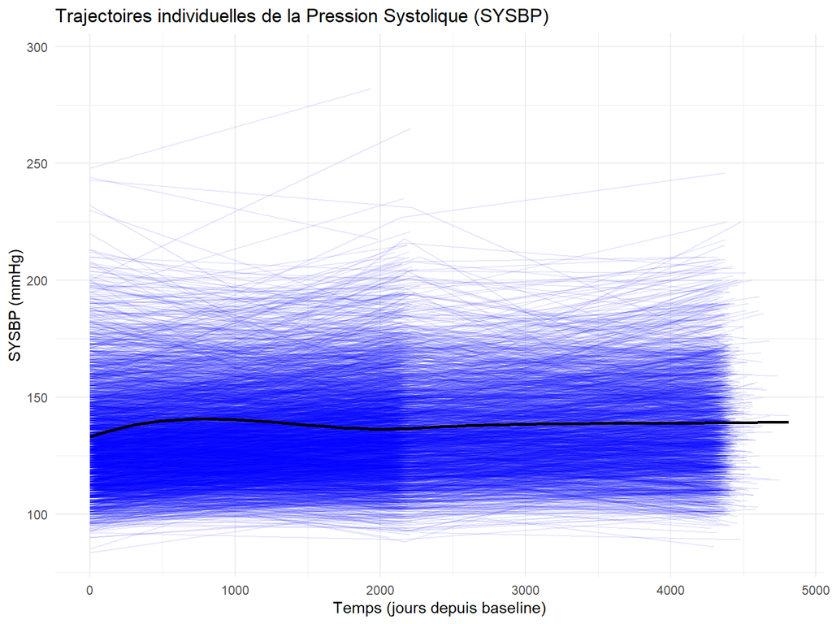

```r
# Thème 1 : SYSBP
p1 <- ggplot(data_long, aes(x = TIME, y = SYSBP, group = RANDID)) +
  geom_line(alpha = 0.1, color = "blue") +
  geom_smooth(aes(group = 1), method = "loess", color = "black", se = FALSE) +
  labs(
    title = "Trajectoires individuelles de la Pression Systolique (SYSBP)",
    x = "Temps (jours depuis baseline)",
    y = "SYSBP (mmHg)"
  ) +
  theme_minimal()

# Thème 2 : TOTCHOL
p2 <- ggplot(data_long, aes(x = TIME, y = TOTCHOL, group = RANDID)) +
  geom_line(alpha = 0.1, color = "red") +
  geom_smooth(aes(group = 1), method = "loess", color = "black", se = FALSE) +
  labs(
    title = "Trajectoires individuelles du Cholestérol Total (TOTCHOL)",
    x = "Temps (jours depuis baseline)",
    y = "TOTCHOL (mg/dL)"
  ) +
  theme_minimal()

# Afficher les graphiques
p1
```

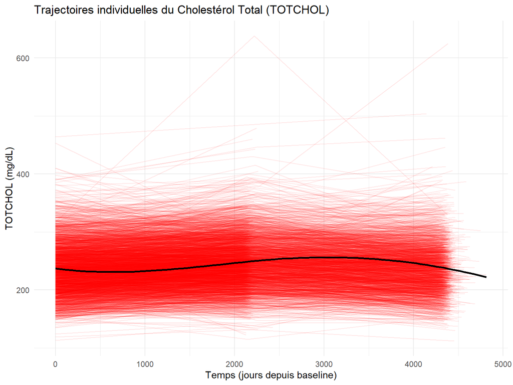

```r
p2
```

### Modélisation (Modèles Linéaires Mixtes - LMM)

Nous utilisons des modèles linéaires à effets mixtes (`lmer`) pour modéliser ces trajectoires, en tenant compte de la corrélation des mesures répétées chez un même individu.

#### Thème 1 (Hypertension)

**Question** : La trajectoire de `SYSBP` diffère-t-elle selon le `SEX`, après ajustement ?

```r
library(lmerTest)

lmer_sysbp <- lmer(SYSBP ~ (PERIOD * SEX) + AGE + BMI + BPMEDS + GLUCOSE + (1 + TIME | RANDID),
                   data = data_long)

# Nettoyage avec broom.mixed et présentation
tidy(lmer_sysbp, conf.int = TRUE, effects = "fixed") %>%
  kbl(
    caption = "Modèle Mixte : Trajectoire de SYSBP",
    digits = 4
  ) %>%
  kable_styling(bootstrap_options = "striped", full_width = T)
```

Modèle Mixte : Trajectoire de SYSBP

| effect | term | estimate | std.error | statistic | df | p.value | conf.low | conf.high |
| --- | --- | --- | --- | --- | --- | --- | --- | --- |
| fixed | (Intercept) | 47.3028 | 2.4455 | 19.3427 | 4245.379 | 0.0000 | 42.5083 | 52.0973 |
| fixed | PERIOD2 | -0.8557 | 0.4737 | -1.8065 | 6620.268 | 0.0709 | -1.7843 | 0.0729 |
| fixed | PERIOD3 | -2.2367 | 0.7153 | -3.1269 | 4300.618 | 0.0018 | -3.6391 | -0.8343 |
| fixed | SEXFemme | 2.9026 | 0.6747 | 4.3020 | 3368.887 | 0.0000 | 1.5797 | 4.2256 |
| fixed | AGE | 0.9051 | 0.0351 | 25.7969 | 3129.625 | 0.0000 | 0.8363 | 0.9739 |
| fixed | BMI | 1.3841 | 0.0654 | 21.1583 | 5677.531 | 0.0000 | 1.2558 | 1.5123 |
| fixed | BPMEDSOui | 5.2427 | 0.6830 | 7.6757 | 6753.077 | 0.0000 | 3.9038 | 6.5817 |
| fixed | GLUCOSE | 0.0363 | 0.0079 | 4.6184 | 8305.108 | 0.0000 | 0.0209 | 0.0517 |
| fixed | PERIOD2:SEXFemme | -0.3347 | 0.5820 | -0.5751 | 4524.328 | 0.5652 | -1.4757 | 0.8062 |
| fixed | PERIOD3:SEXFemme | -1.6341 | 0.7997 | -2.0433 | 2227.605 | 0.0411 | -3.2025 | -0.0658 |

**Interprétation :**

Note : Le modèle utilise `PERIOD` (facteur) pour l’interaction, ce qui est une modélisation flexible, et `TIME` (continu) pour la pente aléatoire.

#### Thème 2 (Cholestérol & Tabac) :

**Question** : La trajectoire de TOTCHOL diffère-t-elle selon le statut tabagique (CURSMOKE), ajusté ?

```r
lmer_chol <- lmer(TOTCHOL ~ (PERIOD * CURSMOKE) + AGE + SEX + BMI + GLUCOSE + (1 + TIME | RANDID),
                  data = data_long)

# Nettoyage et présentation
tidy(lmer_chol, conf.int = TRUE, effects = "fixed") %>%
  kbl(
    caption = "Modèle Mixte : Trajectoire de TOTCHOL",
    digits = 3
  ) %>%
  kable_styling(bootstrap_options = "striped", full_width = T)
```

Modèle Mixte : Trajectoire de TOTCHOL

| effect | term | estimate | std.error | statistic | df | p.value | conf.low | conf.high |
| --- | --- | --- | --- | --- | --- | --- | --- | --- |
| fixed | (Intercept) | 138.147 | 5.639 | 24.499 | 4796.542 | 0.000 | 127.092 | 149.202 |
| fixed | PERIOD2 | 7.270 | 0.939 | 7.742 | 5663.041 | 0.000 | 5.429 | 9.110 |
| fixed | PERIOD3 | -9.715 | 1.329 | -7.311 | 5288.544 | 0.000 | -12.320 | -7.110 |
| fixed | CURSMOKEFumeur | 2.078 | 1.184 | 1.755 | 5511.650 | 0.079 | -0.244 | 4.399 |
| fixed | AGE | 0.941 | 0.080 | 11.695 | 3312.653 | 0.000 | 0.783 | 1.098 |
| fixed | SEXFemme | 11.630 | 1.395 | 8.337 | 3226.437 | 0.000 | 8.895 | 14.365 |
| fixed | BMI | 1.898 | 0.143 | 13.270 | 6430.339 | 0.000 | 1.618 | 2.179 |
| fixed | GLUCOSE | -0.053 | 0.016 | -3.289 | 7998.682 | 0.001 | -0.085 | -0.022 |
| fixed | PERIOD2:CURSMOKEFumeur | 0.281 | 1.236 | 0.228 | 3410.504 | 0.820 | -2.141 | 2.704 |
| fixed | PERIOD3:CURSMOKEFumeur | 1.212 | 1.588 | 0.763 | 2768.685 | 0.445 | -1.902 | 4.326 |

**Interprétation :**

- Terme d’interaction (PERIOD3:CURSMOKEFumeur) : Le terme d’interaction `PERIOD3:CURSMOKEFumeur` n’est statistiquement significatif (p = 0.445).
- Signification : Puisque le terme d’interaction `PERIOD3:CURSMOKEFumeur` n’est pas significatif (p = 0.445), cela signifie que nous n’avons pas de preuve statistique pour affirmer que la différence entre fumeurs et non-fumeurs à la période 3 est différente de celle observée au baseline (période 1).

## Analyse de Survie (Modélisation du Risque)

**Objectif** : Identifier les facteurs de risque au baseline qui prédisent l’incidence des événements (Jeu de données : data_baseline).

### Création des Cohortes d’Incidence

Nous créons deux cohortes :

- Pour l’AVC (STROKE) : Nous excluons les sujets ayant un AVC prévalent (`PREVSTRK == 1`).
- Pour la Maladie Coronarienne (ANYCHD) : Nous excluons les sujets ayant une maladie coronarienne prévalente (`PREVCHD == 1`).

```r
# Cohorte 1 : Incidence d'AVC
data_baseline_stroke_incident <- subset(data_baseline, PREVSTRK == "Non")
# Conversion du statut d'événement en numérique pour survfit
data_baseline_stroke_incident$STROKE <- as.numeric(as.character(data_baseline_stroke_incident$STROKE))

# Cohorte 2 : Incidence de Maladie Coronarienne
data_baseline_chd_incident <- subset(data_baseline, PREVCHD == "Non")
# Conversion du statut d'événement en numérique
data_baseline_chd_incident$ANYCHD <- as.numeric(as.character(data_baseline_chd_incident$ANYCHD))
```

### Visualisation (Courbes de Kaplan-Meier avec survminer)

#### Thème 1 (AVC)

**Comparaison** : Surv(TIMESTRK, STROKE) stratifiée par PREVHYP (Hypertension passée).

pour la création d’un element de survie on a besoin de deux variables event et time, qui sont déjà présent STROKE qui suit 0 l’evenement n’a pas tenue place, 1 a tenue place meme pour event(0 alive, 1 dead) et le temps déjà avec la censure à droite pour les personnes

TIMESTRK Number of days from Baseline exam to first STROKE event during followup or Number of days from Baseline to censor date. Censor date may be end of followup, death or last known contact date if subject is lost to followup.

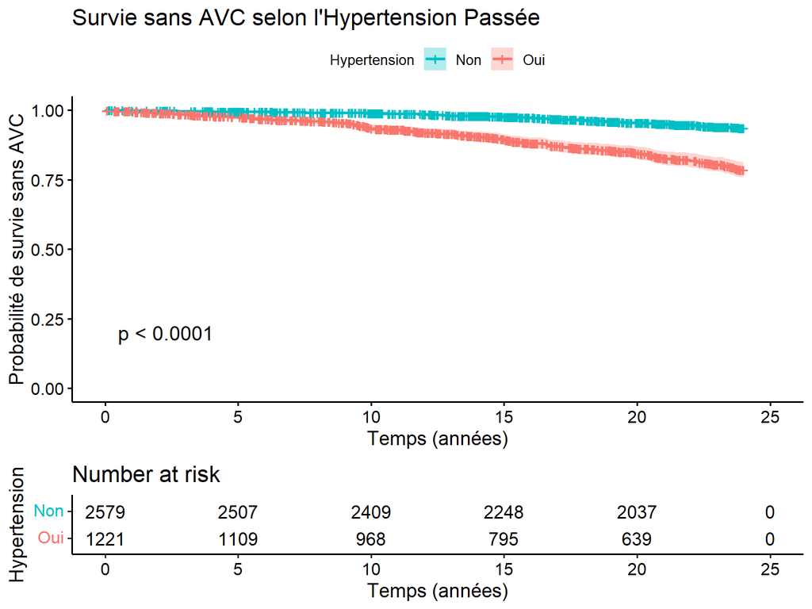

```r
# Conversion de la variable de temps en années (originalement était en jours)
data_baseline_stroke_incident <- data_baseline_stroke_incident %>%
  mutate(TIME_ANNEES = TIMESTRK / 365.25)

fit_km_stroke <- survfit(Surv(TIME_ANNEES, STROKE) ~ PREVHYP, data = data_baseline_stroke_incident)

# Graphique ggsurvplot
ggsurvplot(
  fit_km_stroke,
  data = data_baseline_stroke_incident,
  title = "Survie sans AVC selon l'Hypertension Passée",
  xlab = "Temps (années)",
  ylab = "Probabilité de survie sans AVC",
  pval = TRUE,             # Affiche la p-value du test log-rank
  conf.int = TRUE,         # Intervalle de confiance
  risk.table = TRUE,       # Table des sujets à risque
  legend.title = "Hypertension",
  legend.labs = c("Non", "Oui"),
  palette = c("#00BFC4", "#F8766D")
)
```

**Interprétation :**

La courbe de Kaplan-Meier et le test Log-Rank (p < 0.0001) montrent une différence très significative de la survie sans AVC. Les individus ayant des antécédents d’hypertension (PREVHYP == Oui) ont une probabilité de survie sans AVC nettement inférieure à celle des individus sans antécédents.

#### Thème 2 (Maladie Coronarienne)

Comparaison : Surv(TIMECHD, ANYCHD) stratifiée par CURSMOKE (Statut tabagique).

[figure not shown]

```r
fit_km_chd <- survfit(Surv(TIMECHD, ANYCHD) ~ CURSMOKE, data = data_baseline_chd_incident)

# Graphique ggsurvplot
# M.C = Maladies Coronarienne
ggsurvplot(
  fit_km_chd,
  data = data_baseline_chd_incident,
  title = "Survie sans M.C selon le Statut Tabagique",
  xlab = "Temps (années)",
  ylab = "Probabilité de survie sans M.C",
  pval = TRUE,
  conf.int = TRUE,
  risk.table = TRUE,
  legend.title = "Statut Tabagique",
  legend.labs = c("Non-fumeur", "Fumeur"),
  palette = c("royalblue", "orange")
)
```

### Modélisation (Modèle de Cox - Risques Proportionnels)

Nous utilisons broom::tidy avec exponentiate = TRUE pour obtenir directement les Hazard Ratios (HR).

#### Thème 1 (AVC) :

Question : SYSBP au baseline prédit-il le risque de STROKE, ajusté sur les cofacteurs ?

```r
cox_stroke <- coxph(
  Surv(TIME_ANNEES, STROKE) ~ SYSBP + AGE + SEX + CURSMOKE + DIABETES + BMI + TOTCHOL,
  data = data_baseline_stroke_incident
)

tidy(cox_stroke, exponentiate = TRUE, conf.int = TRUE) %>%
  kbl(
    caption = "Modèle de Cox : Prédicteurs du Risque d'AVC",
    digits = 3
  ) %>%
  kable_styling(bootstrap_options = "striped", full_width = T)
```

Modèle de Cox : Prédicteurs du Risque d’AVC

| term | estimate | std.error | statistic | p.value | conf.low | conf.high |
| --- | --- | --- | --- | --- | --- | --- |
| SYSBP | 1.020 | 0.002 | 8.514 | 0.000 | 1.016 | 1.025 |
| AGE | 1.092 | 0.008 | 11.639 | 0.000 | 1.076 | 1.108 |
| SEXFemme | 0.709 | 0.118 | -2.921 | 0.003 | 0.563 | 0.893 |
| CURSMOKEFumeur | 1.527 | 0.116 | 3.636 | 0.000 | 1.215 | 1.918 |
| DIABETESOui | 2.680 | 0.209 | 4.715 | 0.000 | 1.779 | 4.037 |
| BMI | 1.017 | 0.013 | 1.326 | 0.185 | 0.992 | 1.044 |
| TOTCHOL | 0.998 | 0.001 | -1.835 | 0.067 | 0.995 | 1.000 |

#### Thème 2 (Maladie Coronarienne)

Question : `CURSMOKE` au baseline prédit-il le risque de `ANYCHD`, ajusté ?

```r
cox_chd <- coxph(
  Surv(TIMECHD, ANYCHD) ~ CURSMOKE + AGE + SEX + SYSBP + TOTCHOL + DIABETES + BMI,
  data = data_baseline_chd_incident
)

tidy(cox_chd, exponentiate = TRUE, conf.int = TRUE) %>%
  kbl(
    caption = "Modèle de Cox : Prédicteurs du Risque de Maladie Coronarienne",
    digits = 3
  ) %>%
  kable_styling(bootstrap_options = "striped", full_width = T)
```

Modèle de Cox : Prédicteurs du Risque de Maladie Coronarienne

| term | estimate | std.error | statistic | p.value | conf.low | conf.high |
| --- | --- | --- | --- | --- | --- | --- |
| CURSMOKEFumeur | 1.206 | 0.071 | 2.643 | 0.008 | 1.050 | 1.385 |
| AGE | 1.034 | 0.004 | 7.679 | 0.000 | 1.025 | 1.043 |
| SEXFemme | 0.452 | 0.071 | -11.170 | 0.000 | 0.393 | 0.520 |
| SYSBP | 1.014 | 0.002 | 8.564 | 0.000 | 1.010 | 1.017 |
| TOTCHOL | 1.006 | 0.001 | 7.778 | 0.000 | 1.004 | 1.007 |
| DIABETESOui | 2.171 | 0.148 | 5.229 | 0.000 | 1.624 | 2.903 |
| BMI | 1.039 | 0.008 | 4.519 | 0.000 | 1.022 | 1.056 |

**Interprétation :**

Autres prédicteurs : L’âge, le sexe (Homme), la SYSBP, le TOTCHOL et le diabète sont également des prédicteurs significatifs de la maladie coronarienne.

## Synthèse et Conclusion

Cette analyse, bien que menée sur un sous-échantillon, a permis de mettre en évidence plusieurs associations clés :

Le risque d’AVC est fortement prédit par la SYSBP au baseline, ainsi que par l’âge et le diabète.

Le risque de Maladie Coronarienne est fortement prédit par le statut tabagique (CURSMOKE), l’âge, le sexe, la SYSBP, le TOTCHOL et le diabète.

**Limitation Cruciale (Biais de Sélection)** : Il est fondamental de rappeler la principale limite de cette analyse :

Ces résultats proviennent d’une analyse en cas complets (CCA), qui a exclu 13.7% de la cohorte d’origine au baseline en raison de données manquantes.

Les sujets inclus (ceux sans aucune donnée manquante) sont potentiellement en meilleure santé ou différents de ceux exclus. Ce biais de sélection (ou “biais de données complètes”) signifie que les estimations de risque (HR) et les trajectoires observées peuvent ne pas être généralisables à l’ensemble de la population de Framingham. Des méthodes plus avancées, telles que l’imputation multiple, seraient nécessaires pour adresser ce biais.